# IPTW (chap 10, Lumley, 2010)

Exploring the data and models introduced in the causal chapter of Lumley’s (2010) book on surveys – and a few other models to see how they compare.

```r
library(tidyverse)
library(janitor)
library(survey)
library(srvyr)
library(modelsummary)
# LMMs
library(lme4)

# CEM
library(MatchIt)
library(lmtest)   #coeftest
library(sandwich) #vcovCL
```

The data are [over here](https://www.cengage.com/cgi-wadsworth/course_products_wp.pl?fid=M20b&product_isbn_issn=9781305268920), in a collection from another book mentioned by Lumley.

```r
dat <- read.csv("kidsmoking.txt", sep = "\t")
head(dat)
```

|  | id | age | fev1 | height | sex | smoke |
| --- | --- | --- | --- | --- | --- | --- |
| 1 | 301 | 9 | 1.708 | 57.0 | 0 | 0 |
| 2 | 451 | 8 | 1.724 | 67.5 | 0 | 0 |
| 3 | 501 | 7 | 1.720 | 54.5 | 0 | 0 |
| 4 | 642 | 9 | 1.558 | 53.0 | 1 | 0 |
| 5 | 901 | 9 | 1.895 | 57.0 | 1 | 0 |
| 6 | 1701 | 8 | 2.336 | 61.0 | 0 | 0 |

It has the right number of rows – first good sign that it’s the same dataset.

```r
nrow(dat)
```

```
[1] 654
```

Fix the factors:

```r
dat <- dat %>%
  mutate(smoke = factor(smoke),
         smoke = recode(smoke, `0` = "No", `1` = "Yes"),
         sex   = factor(sex),
         sex   = recode(sex, `0` = "Female", `1` = "Male"))
```

Lumley mentions a family ID, but it’s not there. My guess is that it’s embedded in the overall ID with the last two digits providing the child ID and the rest the family. Let’s give that a go.

```r
dat <- dat %>%
  mutate(family_id = floor(id/100))
```

Should be 290 families:

```r
unique(dat$family_id) %>% length()
```

```
[1] 290
```

YES.

Now we need a variable to encode whether each child has a sibling who smokes. For each family we can count the total number of (child) smokers. Then for a given child we work out if a sib smokes by rule:

Does child of focus smoke? If yes, then sib smokes if are there 2 or more smokers in the family. If no, then sib smokes if are there 1 or more smokers in the family.

Let’s give that a go. First, count the child smokers in each family.

```r
fam_smokers <- dat %>%
  group_by(family_id) %>%
  summarise(fam_smokers = sum(smoke == "Yes"))
```

Merge the count back into the dataframe and work out whether each child has a sib who smokes:

```r
dat <- dat %>%
  left_join(fam_smokers) %>%
  mutate(
    sib_smokes = ifelse(smoke == "Yes",
                             fam_smokers >= 2,
                        #else
                             fam_smokers >= 1)
  )
```

Done.

Finally, make the IDs factors.

```r
dat <- dat %>%
  mutate(id = factor(id),
         family_id = factor(family_id))
```

Now some pictures:

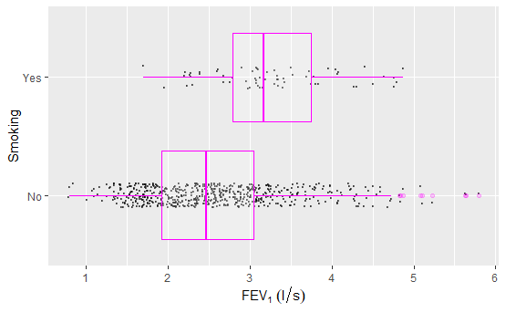

```r
dat %>%
  ggplot(aes(smoke, fev1)) +
  geom_jitter(width = 0.1, alpha = 0.5, size = 0.5) +
  geom_boxplot(alpha = 0.2, colour = "magenta") +
  labs(x = "Smoking",
       y = expression(FEV[1]~(l/s))) +
  coord_flip()
```

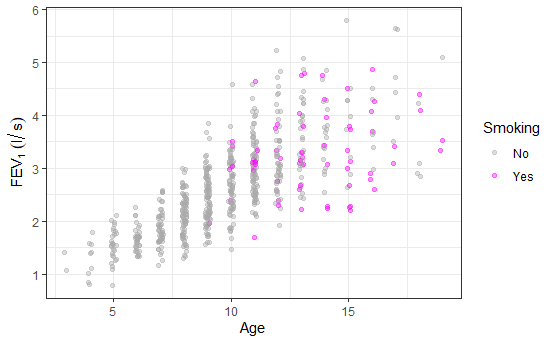

```r
set.seed(1337)
dat %>%
  ggplot(aes(age, fev1, colour = smoke)) +
  geom_jitter(alpha = 0.4, width = 0.1, height = 0) +
  labs(x = "Age",
       y = expression(FEV[1]~(l/s)),
       colour = "Smoking") +
  scale_colour_manual(values = c("darkgrey", "magenta")) +
  theme_bw()
```

what’s the earliest age someone smokes?

```r
dat %>%
  mutate(age = ordered(age)) %>%
  tabyl(age, smoke)
```

```
 age No Yes
   3  2   0
   4  9   0
   5 28   0
   6 37   0
   7 54   0
   8 85   0
   9 93   1
  10 76   5
  11 81   9
  12 50   7
  13 30  13
  14 18   7
  15  9  10
  16  6   7
  17  6   2
  18  4   2
  19  1   2
```

It’s 9, but, as Lumley points out, it’s only one person.

```r
dat10plus <- dat %>%
  filter(age >= 10)
```

Just going to copy the analyses to start with, to check it’s really the same dataset:

```r
m1  <- glm(I(smoke == "Yes") ~ age * sex, data = dat10plus,
           family = binomial)
m2  <- glm(I(smoke == "Yes") ~ height * sex, data = dat10plus,
           family = binomial)
m1a <- glm(I(smoke == "Yes") ~ (age + sib_smokes) * sex, data = dat10plus,
           family = binomial)
m2a <- glm(I(smoke == "Yes") ~ (height + sib_smokes) * sex, data = dat10plus,
           family = binomial)
```

```r
dat10plus <- dat10plus %>%
  mutate(
    pi1 = ifelse(smoke == "Yes",
                 fitted(m1),
                 1 - fitted(m1)),
    pi2 = ifelse(smoke == "Yes",
                 fitted(m2),
                 1 - fitted(m2)),
    pi1a = ifelse(smoke == "Yes",
                  fitted(m1a),
                  1 - fitted(m1a)),
    pi2a = ifelse(smoke == "Yes",
                  fitted(m2a),
                  1 - fitted(m2a)),
    w1 = 1 / pi1,
    w2 = 1 / pi2,
    w1a = 1 / pi1a,
    w2a = 1 / pi2a
  )
```

Note below I had apparently confused `as_survey` by including a formula in the weights option: the reciprocal of the propensity score. Easily fixed and a reminder to check the design object is setup correctly before using it in analyses.

```r
the_designs <- list()

the_designs[["m1"]] <- dat10plus %>%
  as_survey(ids = family_id,
            weights = w1)

the_designs[["m2"]] <- dat10plus %>%
  as_survey(ids = family_id,
            weights = w2)

the_designs[["m1a"]] <- dat10plus %>%
  as_survey(ids = family_id,
            weights = w1a)

the_designs[["m2a"]] <- dat10plus %>%
  as_survey(ids = family_id,
            weights = w2a)

the_designs[["unweighted"]] <- dat10plus %>%
  as_survey(ids = family_id,
            weights = NULL)
```

```r
the_designs
```

```
$m1
1 - level Cluster Sampling design (with replacement)
With (209) clusters.
Called via srvyr
Sampling variables:
 - ids: family_id
 - weights: w1
Data variables: id (int), age (int), fev1 (dbl), height (dbl),
  sex (fct), smoke (fct), family_id (dbl), fam_smokers (int),
  sib_smokes (lgl), pi1 (dbl), pi2 (dbl), pi1a (dbl), pi2a (dbl),
  w1 (dbl), w2 (dbl), w1a (dbl), w2a (dbl)

$m2
1 - level Cluster Sampling design (with replacement)
With (209) clusters.
Called via srvyr
Sampling variables:
 - ids: family_id
 - weights: w2
Data variables: id (int), age (int), fev1 (dbl), height (dbl),
  sex (fct), smoke (fct), family_id (dbl), fam_smokers (int),
  sib_smokes (lgl), pi1 (dbl), pi2 (dbl), pi1a (dbl), pi2a (dbl),
  w1 (dbl), w2 (dbl), w1a (dbl), w2a (dbl)

$m1a
1 - level Cluster Sampling design (with replacement)
With (209) clusters.
Called via srvyr
Sampling variables:
 - ids: family_id
 - weights: w1a
Data variables: id (int), age (int), fev1 (dbl), height (dbl),
  sex (fct), smoke (fct), family_id (dbl), fam_smokers (int),
  sib_smokes (lgl), pi1 (dbl), pi2 (dbl), pi1a (dbl), pi2a (dbl),
  w1 (dbl), w2 (dbl), w1a (dbl), w2a (dbl)

$m2a
1 - level Cluster Sampling design (with replacement)
With (209) clusters.
Called via srvyr
Sampling variables:
 - ids: family_id
 - weights: w2a
Data variables: id (int), age (int), fev1 (dbl), height (dbl),
  sex (fct), smoke (fct), family_id (dbl), fam_smokers (int),
  sib_smokes (lgl), pi1 (dbl), pi2 (dbl), pi1a (dbl), pi2a (dbl),
  w1 (dbl), w2 (dbl), w1a (dbl), w2a (dbl)

$unweighted
1 - level Cluster Sampling design (with replacement)
With (209) clusters.
Called via srvyr
Sampling variables:
 - ids: family_id
Data variables: id (int), age (int), fev1 (dbl), height (dbl),
  sex (fct), smoke (fct), family_id (dbl), fam_smokers (int),
  sib_smokes (lgl), pi1 (dbl), pi2 (dbl), pi1a (dbl), pi2a (dbl),
  w1 (dbl), w2 (dbl), w1a (dbl), w2a (dbl)
```

```r
the_mods <- lapply(the_designs, \(d) svyglm(fev1 ~ smoke, design = d))
the_mods[["LMM"]] <- lmer(fev1 ~ smoke + (1|family_id),
                                 data = dat10plus)
```

```r
modelsummary(the_mods,
             fmt = 2,
             gof_omit = ".*",
             coef_map = c("smokeYes" = "Smoking"))
```

|  | m1 | m2 | m1a | m2a | unweighted | LMM |
| --- | --- | --- | --- | --- | --- | --- |
| Smoking | 0.11 | 0.03 | 0.19 | 0.17 | 0.15 | 0.19 |
|  | (0.13) | (0.16) | (0.15) | (0.13) | (0.10) | (0.10) |

The coefficients are still pointing the wrong way: smoking implies better lung capacity. Lumley tries the analysis again by subseting to children aged 12 or above and with a doubly-robust approach, also known as augmented IPW (AIPW). I’m curious to see what happens with coarsened exact matching.

```r
mat <- matchit(smoke ~ age + height + sex + sib_smokes,
               data = dat10plus,
               method = "cem",
               estimate = "ATE")
mat
```

```
A matchit object
 - method: Coarsened exact matching
 - number of obs.: 345 (original), 129 (matched)
 - target estimand: ATT
 - covariates: age, height, sex, sib_smokes
```

```r
summary(mat)
```

```
Call:
matchit(formula = smoke ~ age + height + sex + sib_smokes, data = dat10plus,
    method = "cem", estimate = "ATE")

Summary of Balance for All Data:
               Means Treated Means Control Std. Mean Diff.
age                  13.5938       11.8043          0.7825
height               66.0781       64.6616          0.4636
sexFemale             0.6094        0.4413          0.3445
sexMale               0.3906        0.5587         -0.3445
sib_smokesTRUE        0.3438        0.1708          0.3641
               Var. Ratio eCDF Mean eCDF Max
age                1.4697    0.1789   0.4085
height             0.6335    0.0881   0.2177
sexFemale               .    0.1681   0.1681
sexMale                 .    0.1681   0.1681
sib_smokesTRUE          .    0.1729   0.1729


Summary of Balance for Matched Data:
               Means Treated Means Control Std. Mean Diff.
age                  12.5135       12.5135           0.000
height               66.2568       65.9878           0.088
sexFemale             0.6216        0.6216           0.000
sexMale               0.3784        0.3784           0.000
sib_smokesTRUE        0.2162        0.2162           0.000
               Var. Ratio eCDF Mean eCDF Max Std. Pair Dist.
age                1.0112    0.0000   0.0000          0.0000
height             0.8981    0.0222   0.1149          0.2456
sexFemale               .    0.0000   0.0000          0.0000
sexMale                 .    0.0000   0.0000          0.0000
sib_smokesTRUE          .    0.0000   0.0000          0.0000

Percent Balance Improvement:
               Std. Mean Diff. Var. Ratio eCDF Mean eCDF Max
age                        100       97.1     100.0    100.0
height                      81       76.5      74.8     47.2
sexFemale                  100          .     100.0    100.0
sexMale                    100          .     100.0    100.0
sib_smokesTRUE             100          .     100.0    100.0

Sample Sizes:
              Control Treated
All             281.       64
Matched (ESS)    61.9      37
Matched          92.       37
Unmatched       189.       27
Discarded         0.        0
```

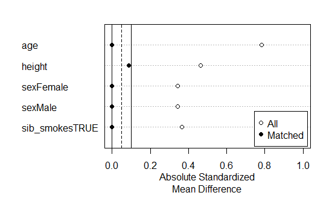

Here’s what the help recommends:

```r
mat_dat <- match.data(mat)
cem_fit <- lm(fev1 ~ smoke, data = mat_dat, weights = weights)
coeftest(cem_fit, vcov. = vcovCL, cluster = ~subclass)
```

```
t test of coefficients:

            Estimate Std. Error t value Pr(>|t|)
(Intercept) 3.340655   0.103134 32.3913   <2e-16 ***
smokeYes    0.061724   0.089078  0.6929   0.4896
---
Signif. codes:  0 ‘***’ 0.001 ‘**’ 0.01 ‘*’ 0.05 ‘.’ 0.1 ‘ ’ 1
```

Try also using {survey}:

```r
cem_design <- mat_dat %>%
  as_survey(
    ids = subclass,
    weights = weights
  )
cem_design
```

```
1 - level Cluster Sampling design (with replacement)
With (32) clusters.
Called via srvyr
Sampling variables:
 - ids: subclass
 - weights: weights
Data variables: id (int), age (int), fev1 (dbl), height (dbl),
  sex (fct), smoke (fct), family_id (dbl), fam_smokers (int),
  sib_smokes (lgl), pi1 (dbl), pi2 (dbl), pi1a (dbl), pi2a (dbl),
  w1 (dbl), w2 (dbl), w1a (dbl), w2a (dbl), weights (dbl),
  subclass (fct)
```

```r
svyglm(fev1 ~ smoke, design = cem_design) %>%
  summary()
```

```
Call:
svyglm(formula = fev1 ~ smoke, design = cem_design)

Survey design:
Called via srvyr

Coefficients:
            Estimate Std. Error t value Pr(>|t|)
(Intercept)  3.34065    0.10273  32.519   <2e-16 ***
smokeYes     0.06172    0.08873   0.696    0.492
---
Signif. codes:  0 ‘***’ 0.001 ‘**’ 0.01 ‘*’ 0.05 ‘.’ 0.1 ‘ ’ 1

(Dispersion parameter for gaussian family taken to be 0.4161119)

Number of Fisher Scoring iterations: 2
```

Also try a multilevel model with the weights. {WeMix} seems to do it.